# Textual Data

Jilly MacKay

17 April 2018

## A Fundamental Assertion

All ‘data science’ does is condense *lots of data* into a *smaller bit of data*.

For example:

```r
lots.of.data <- runif(100, min = 0, max = 100)
```

## A Fundamental Assertion

All ‘data science’ does is condense *lots of data* into a *smaller bit of data*.

If I asked you to interpret that data, you would *not* say:

```r
print(lots.of.data)
```

## A Fundamental Assertion

All ‘data science’ does is condense *lots of data* into a *smaller bit of data*.

If I asked you to interpret that data, you would *not* say:

```r
print(lots.of.data)
```

```
##   [1]  8.6302296 32.0260955  0.7890096 56.8000413 16.6209505 50.7232395
##   [7] 42.1301862 46.8415494 52.7986975 82.9593671 23.1387967 13.2803089
##  [13]  5.2018765 79.8619604 87.0025008 19.2353352 38.5492044  4.0139022
##  [19] 95.4621185 49.2954886 75.9981796 99.5259539 87.2597942 93.4480967
##  [25] 86.4764187 12.1531336 41.8749794 42.8160740 56.3362168 92.6683144
##  [31]  9.5831759 90.6668513 74.1464061 62.1230174 65.5127098 41.5624570
##  [37]  0.1377495 49.9763527 83.4478161 96.7478529 40.6761999 59.3121295
##  [43] 79.2956270 19.6297228 58.3562123 83.5149730 18.2987315 55.4559481
##  [49] 15.5874688 58.7995894 91.8538454 75.8803279 20.0111490 23.9401339
##  [55] 50.9527105 67.4855503 23.0922522 43.9597382 76.8046381 28.9710926
##  [61] 68.6128499 76.1547139 67.8241831  2.6138303 83.4799183 76.8284561
##  [67] 77.7276283 21.1477514 48.3125574 45.5307719 91.9565442 14.0586324
##  [73] 31.0509891 85.0433275 80.5547127 21.7778144 47.9596373 19.0045922
##  [79] 40.3103141 72.3606414 99.6415812  3.0885597 30.8388799 55.4777448
##  [85] 75.4198108 87.7756892  0.4449143  3.6626568 62.2274183 15.2738946
##  [91] 59.4731085 79.7140778 64.2291696 32.3086947 13.6032424 30.7764864
##  [97] 81.4181790  5.5589318 81.5309178 18.4972069
```

## Dealing with Lots of Data

To interpret *lots of data* you would instead likely do something like:

```r
mean(lots.of.data)
```

```
## [1] 50.32971
```

```r
sd(lots.of.data)
```

```
## [1] 29.73246
```

## Dealing with Lots of Data

To interpret *lots of data* you would instead likely do something like:

```r
mean(lots.of.data)
```

```
## [1] 50.32971
```

```r
sd(lots.of.data)
```

```
## [1] 29.73246
```

The rest is just quibbling over methodology (which is extremely fun to do!)

```r
median(lots.of.data)
```

```
## [1] 50.83797
```

## Textual Data

In the same way, if you have a large chunk of text, you do not ‘analyse’ it by saying …

```r
print(lotta.text)
```

```
## # A tibble: 4,447 x 1
##                                                                  text
##                                                                 <chr>
##  1                                                Transcriber's Note:
##  2 Punctuation, Spelling and Geographical errors retained as found in
##  3                                                      the original.
##  4
##  5
##  6
##  7
##  8                                                     _DOG STORIES._
##  9
## 10
## # ... with 4,437 more rows
```

## Textual Data

There are three main ways to analyse textual data in R

- As corpora (`tm`)
- As tidytext (`tidytext`)
- Thematically (`RQDA`)

(*Lets use a simpler example than `lottatext`*)

```r
data <-  c("",
           "word1",
           "word1 word2",
           "word1 word2 word3",
           "word1 word2 word3 word4",
           "word1 word2 word3 word4 word5")
```

## The tm Package

The `tm` package is about ‘text mining’ and treats text as a ‘corpus’ (or many ‘corpora’).

The basic command is:

```r
tm.text <- Corpus(VectorSource(data))
```

Where `Corpus` reads in the data.

`VectorSource` tells `Corpus` to expect the source file to be in a vector format.

## The tm Package

A corpus can be thought of as a document of documents.

In this case, using the command `VectorSource` has each ‘row’ of the example data as a new document.

If you have multiple big text files in a folder you can use `DirSource` as opposed to `VectorSource`

`DirSource` will read all the documents in the directory it’s pointed to.

Think of each document as an ‘observation’.

## Document Term Matrices vs Term Document Matrices

Tutorials often use these interchangeably, but there are times you want one, and times you want the other.

The key difference is that `DocumentTermMatrix` has documents listed in the first **column**

```r
dtm.data <- DocumentTermMatrix(tm.text)
head(as.matrix(dtm.data))
```

```
##     Terms
## Docs word1 word2 word3 word4 word5
##    1     0     0     0     0     0
##    2     1     0     0     0     0
##    3     1     1     0     0     0
##    4     1     1     1     0     0
##    5     1     1     1     1     0
##    6     1     1     1     1     1
```

## Document Term Matrices vs Term Document Matrices

Versus the `TermDocumentMatrix` has documents listed in the first **row**

```r
tdm.data <- TermDocumentMatrix(tm.text)
head(as.matrix(tdm.data))
```

```
##        Docs
## Terms   1 2 3 4 5 6
##   word1 0 1 1 1 1 1
##   word2 0 0 1 1 1 1
##   word3 0 0 0 1 1 1
##   word4 0 0 0 0 1 1
##   word5 0 0 0 0 0 1
```

## Using Document Term Matrices for Frequency

You can explore datasets quickly using these matrices.

```r
# TermDocumentMatrix
tdm.m <- as.matrix(tdm.data)
tdm.v <- sort(rowSums(tdm.m), decreasing = TRUE)
tdm.d <- data.frame(word = names(tdm.v), freq = tdm.v)
head(tdm.d, 10)
```

```
##        word freq
## word1 word1    5
## word2 word2    4
## word3 word3    3
## word4 word4    2
## word5 word5    1
```

## Exploring Frequency with tm Commands

There are a few interesting commands in the `tm` package which are frequently found in online tutorials (there are caveats to how they work though)

```r
#Find the top 3 terms
findFreqTerms(tdm.data, 3)
```

```
## [1] "word1" "word2" "word3"
```

```r
#Find correlations above 0 with Word 1 (Pearson correlations, 0 is lower limit)
findAssocs(tdm.data, "word1", 0)
```

```
## $word1
## word2 word3 word4 word5
##  0.63  0.45  0.32  0.20
```

## Word Clouds

People love to visualise text data with word clouds, even though they’re just difficult-to-read bar charts. You can create them with the `wordcloud` package.

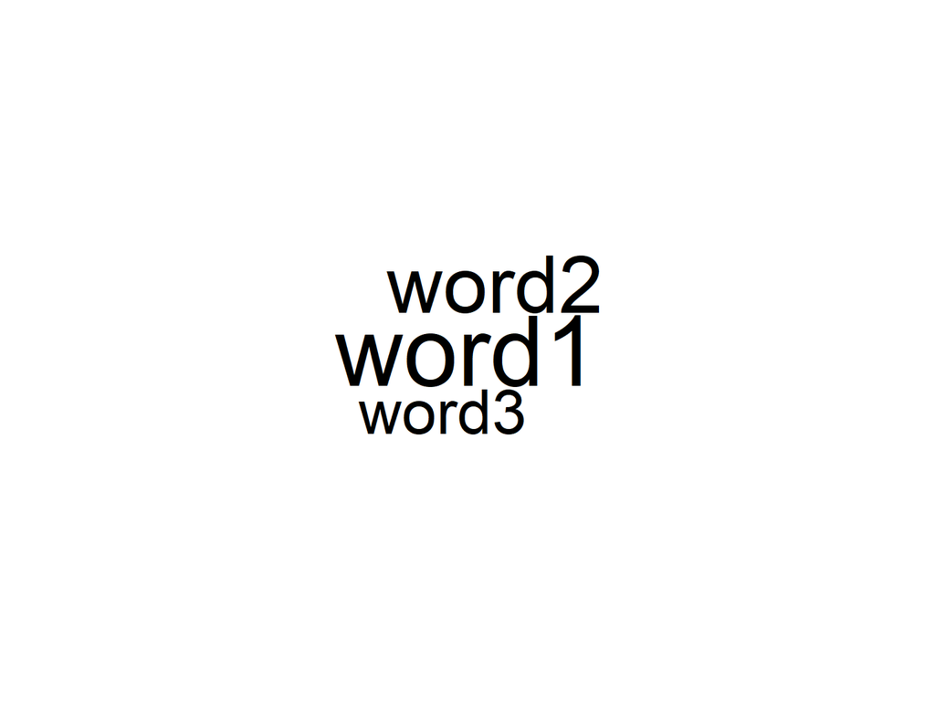

```r
wordle <- wordcloud(tm.text, scale = c(5,0.5), max.words = 10, random.order = FALSE, random.color = FALSE, rot.per = 0, use.r.layout = FALSE)
```

```r
wordle
```

## tm versus tidytext

The `tm` package is very good at word frequency, and very little else.

My preferred alternative is `tidytext`.

Corpora are documents as you or I would read them. `tidytext` converts text into tidy data.

```r
data_tb <- tibble(text = data)

#This command unnests all the words so every word is on a new row sequentially
data_tb_un <- data_tb %>%
    unnest_tokens(word, text)
```

## Using tidytext for Frequency Analysis

```r
data_freq <- data_tb_un %>%
  count (word, sort =TRUE)
data_freq
```

```
## # A tibble: 5 x 2
##    word     n
##   <chr> <int>
## 1 word1     5
## 2 word2     4
## 3 word3     3
## 4 word4     2
## 5 word5     1
```

## Using tidytext for Frequency Analysis

```r
data_freq <- data_tb_un %>%
  count (word, sort =TRUE)
data_freq
```

```
## # A tibble: 5 x 2
##    word     n
##   <chr> <int>
## 1 word1     5
## 2 word2     4
## 3 word3     3
## 4 word4     2
## 5 word5     1
```

Like all tidyverse stuff, this can be built up in oniony layers

```r
data_freq <- data_tb_un %>%
  count(word, sort = TRUE) %>%
  top_n (3)
data_freq
```

```
## # A tibble: 3 x 2
##    word     n
##   <chr> <int>
## 1 word1     5
## 2 word2     4
## 3 word3     3
```

## Using tidytext for Frequency Analysis

This can also be visualised like so:

```r
data_freq <- data_tb_un %>%
  count(word, sort = TRUE) %>%
  top_n (3) %>%
  ungroup() %>%
  mutate(text_order = nrow(.):1)
```

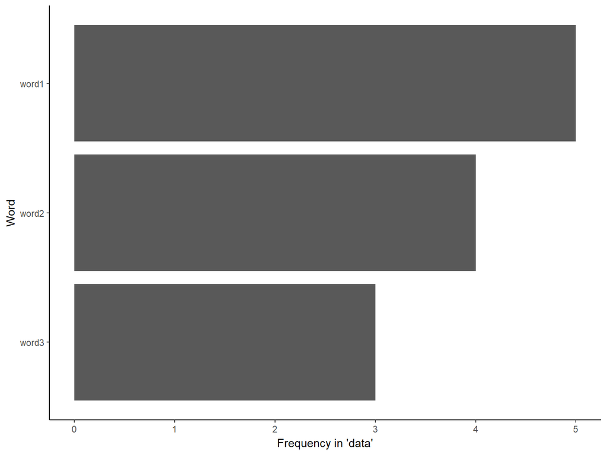

```r
ggplot (data = data_freq, aes(reorder(word, text_order), n)) +
  geom_bar (stat = "identity") +
  labs(x = "Word", y= "Frequency in 'data'") +
  coord_flip()+
  theme_classic()
```

## Word Associations via n-grams

Instead of a tibble where each word is on a different row . . .

Create a tibble where each row is a sequential pair of words (bigrams).

This creates repetition, in the first two rows of the new tibble `data_eng` there is an overlap, row1-column2’s ‘word1’ is the same as row2-column1’s ‘word1’

```r
data_eng <- data_tb %>%
    unnest_tokens(bigram, text, token = "ngrams", n = 2)

data_eng
```

```
## # A tibble: 14 x 1
##         bigram
##          <chr>
##  1 word1 word1
##  2 word1 word2
##  3 word2 word1
##  4 word1 word2
##  5 word2 word3
##  6 word3 word1
##  7 word1 word2
##  8 word2 word3
##  9 word3 word4
## 10 word4 word1
## 11 word1 word2
## 12 word2 word3
## 13 word3 word4
## 14 word4 word5
```

## Word Associations via n-grams

We can count the bigrams in the same way as before

```r
bigramcount <- data_eng %>%
  count (bigram, sort = TRUE)
bigramcount
```

```
## # A tibble: 8 x 2
##        bigram     n
##         <chr> <int>
## 1 word1 word2     4
## 2 word2 word3     3
## 3 word3 word4     2
## 4 word1 word1     1
## 5 word2 word1     1
## 6 word3 word1     1
## 7 word4 word1     1
## 8 word4 word5     1
```

## Word Associations via n-grams

We can count the bigrams in the same was as before

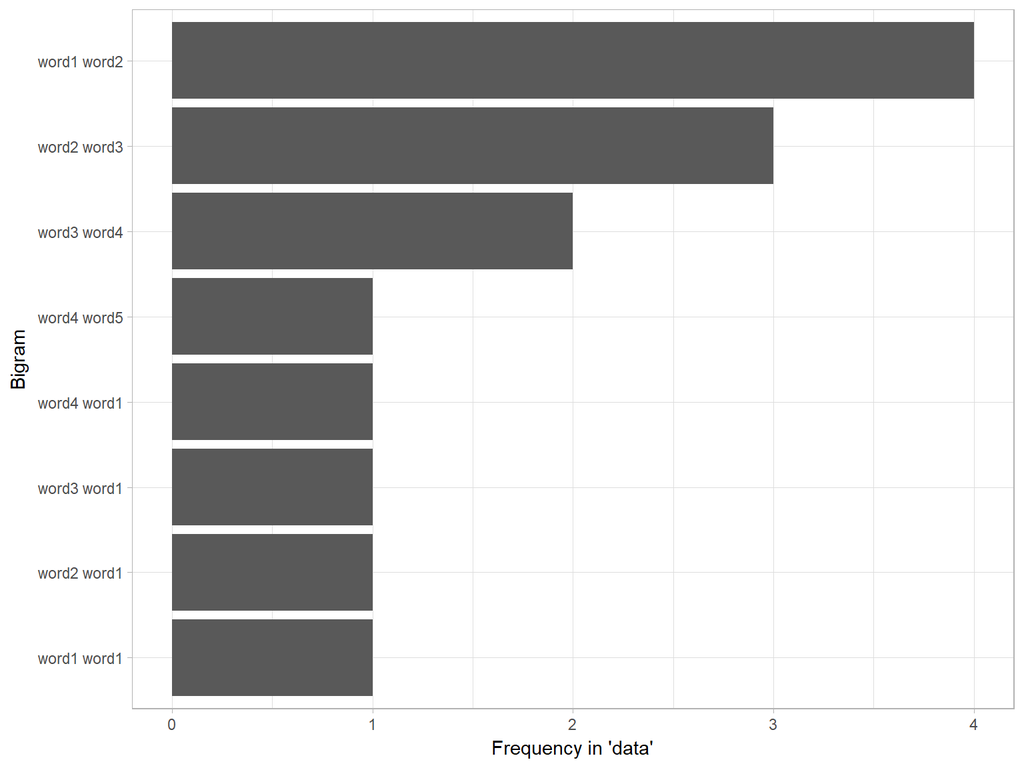

```r
ggplot (data = bigramcount, aes(x = (reorder(bigram,n)), y = n)) +
  geom_bar (stat = "identity") +
  labs(x = "Bigram", y= "Frequency in 'data'") +
  coord_flip()+
  theme_light()
```

## Wordles With tidytext

You can still use the `wordcloud` command with tidytext format data.

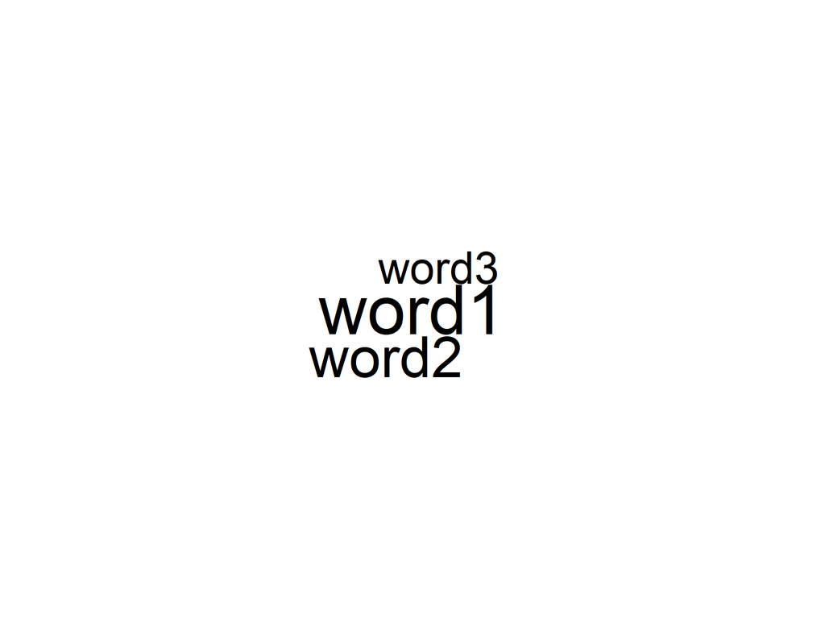

```r
tidywordle <- data_freq %>%
  with (wordcloud(words = word, freq = n, random.order = FALSE, rot.per = 0, use.r.layout = FALSE))
```

```r
tidywordle
```

## RQDA

`RQDA` is a package which allows R to ‘code’ free-text data. ‘Coding’ in this context, means ‘categorising’.

R cannot thematically analyse text **for** you. It can only organise your categories.

`RQDA` is available [here - http://rqda.r-forge.r-project.org/](http://rqda.r-forge.r-project.org/). There are a few intermediary steps to installing `RQDA`, as it requires GTK+ to work.

## RQDA

We’re going to use a document which is freely available from the Gutenberg Project, (Dog Stories from the Spectator)[http://www.gutenberg.org/ebooks/31847].

```r
#To open RQDA
RQDA()
```

A new window will open …

## RQDA

[figure not shown]

Opening RQDA

## RQDA

[figure not shown]

Create a new project

## RQDA

[figure not shown]

In the ‘files’ tab, you can associate text with the project

## RQDA

[figure not shown]

Specify your text files

## RQDA

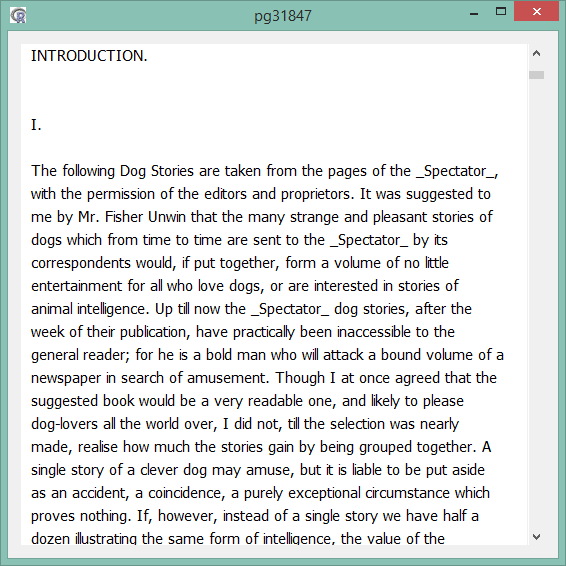

Now in qualitative analysis, you will read through your text files (many, many times)

## RQDA

[figure not shown]

Next is the ‘code’ tab, where you can start to note down the themes that arise in your text

## RQDA

[figure not shown]

You can ‘add’ codes (or themes) apriori, like so

## RQDA

[figure not shown]

And you’ll end up with multiple codes like so.

## RQDA

[figure not shown]

The ‘meat’ of qual analysis is to find the interesting information and ‘file’ it to a code.

## RQDA

[figure not shown]

Here we’ll add a new code, ‘Dog Wisdom’

## RQDA

[figure not shown]

Once the code is created, highlight the text, ensure the correct code is highlighted, and click ‘mark’

## RQDA

You can then pull up all the text within a given code and code within or review that text.

## Free Text Three Ways

At the end of the day, all three methods have their strengths.

- Corpora are traditional methods of exploring frequency, and can be explored with time.
- Tidytext is a highly repeatable and robust way of dealing with text data
- Qualitative analysis is really the only way to explore the linkages of themes.

Happy text mining!

## Fin

*FIN*